# Healthy Hearts

David Rucinski

November 7, 2019

## **Objective**

To showcase and practice machine learning techniques and visualizations.

## Packages

```r
library(data.table)  #fread()
library(ggplot2)
library(dplyr)       #The usual
library(caret)       #train()
library(rsample)     #initial_split() vfold_cv()
library(purrr)       #map()
library(Metrics)     #recall() mae()
library(ranger)      #ranger()
library(glmnet)      #glmnet()
library(broom)       #map()
library(ggthemes)    #theme_
```

## **Data**

Source: The data comes from [kaggle](https://www.kaggle.com/ronitf/heart-disease-uci) where a user had subset the data from the [UCI](https://archive.ics.uci.edu/ml/datasets/Heart+Disease) machine learning repository.

### Importing

```r
heart <- fread("heart.csv", header = TRUE)
heart.c <- fread("heart.csv", header = TRUE)

glimpse(heart)
```

```
Observations: 1,025
Variables: 14
$ age      <int> 52, 53, 70, 61, 62, 58, 58, 55, 46, 54, 71, 43, 34, 5...
$ sex      <int> 1, 1, 1, 1, 0, 0, 1, 1, 1, 1, 0, 0, 0, 1, 1, 0, 0, 1,...
$ cp       <int> 0, 0, 0, 0, 0, 0, 0, 0, 0, 0, 0, 0, 1, 0, 0, 1, 2, 0,...
$ trestbps <int> 125, 140, 145, 148, 138, 100, 114, 160, 120, 122, 112...
$ chol     <int> 212, 203, 174, 203, 294, 248, 318, 289, 249, 286, 149...
$ fbs      <int> 0, 1, 0, 0, 1, 0, 0, 0, 0, 0, 0, 1, 0, 0, 1, 0, 0, 0,...
$ restecg  <int> 1, 0, 1, 1, 1, 0, 2, 0, 0, 0, 1, 0, 1, 1, 1, 1, 0, 0,...
$ thalach  <int> 168, 155, 125, 161, 106, 122, 140, 145, 144, 116, 125...
$ exang    <int> 0, 1, 1, 0, 0, 0, 0, 1, 0, 1, 0, 1, 0, 1, 1, 0, 0, 1,...
$ oldpeak  <dbl> 1.0, 3.1, 2.6, 0.0, 1.9, 1.0, 4.4, 0.8, 0.8, 3.2, 1.6...
$ slope    <int> 2, 0, 0, 2, 1, 1, 0, 1, 2, 1, 1, 1, 2, 1, 1, 2, 2, 1,...
$ ca       <int> 2, 0, 0, 1, 3, 0, 3, 1, 0, 2, 0, 0, 0, 3, 0, 0, 1, 1,...
$ thal     <int> 3, 3, 3, 3, 2, 2, 1, 3, 3, 2, 2, 3, 2, 3, 0, 2, 2, 3,...
$ target   <int> 0, 0, 0, 0, 0, 1, 0, 0, 0, 0, 1, 0, 1, 0, 0, 1, 1, 0,...
```

### Cleaning

```r
##### For a Little bit of clarity of variables
list_names <- c("Age" , "Gender", "ChestPain", "RestingBloodPressure", "Cholestrol", "FastingBloodSugar", "RestingECG", "MaxHeartRateAchivied", "ExerciseIndusedAngina", "Oldpeak", "Slope", "MajorVessels", "Thalassemia", "Target")

colnames(heart) <- list_names
colnames(heart.c) <- list_names
```

```r
heart$Gender <-  as.factor(heart$Gender)
heart$ChestPain <- as.factor(heart$ChestPain)
heart$ExerciseIndusedAngina <- as.factor(heart$ExerciseIndusedAngina)
heart$Thalassemia <- as.factor(heart$Thalassemia)
heart$Target <- as.factor(heart$Target)
```

```r
# levels(heart$ChestPain)

heart <- transform(heart,
          ChestPain=plyr::revalue(ChestPain,c("0"="Typical Angina", "1"="Atypical Angina", "2"="Non-Anginal", "3"="Asymptomatic")))

heart <- transform(heart,
          Gender=plyr::revalue(Gender, c("0"="Female", "1"="Male")))


heart <- transform(heart,
          Target=plyr::revalue(Target, c("0"="Healthy Heart", "1"="Heart Disease")))

glimpse(heart)
```

```
Observations: 1,025
Variables: 14
$ Age                   <int> 52, 53, 70, 61, 62, 58, 58, 55, 46, 54, ...
$ Gender                <fct> Male, Male, Male, Male, Female, Female, ...
$ ChestPain             <fct> Typical Angina, Typical Angina, Typical ...
$ RestingBloodPressure  <int> 125, 140, 145, 148, 138, 100, 114, 160, ...
$ Cholestrol            <int> 212, 203, 174, 203, 294, 248, 318, 289, ...
$ FastingBloodSugar     <int> 0, 1, 0, 0, 1, 0, 0, 0, 0, 0, 0, 1, 0, 0...
$ RestingECG            <int> 1, 0, 1, 1, 1, 0, 2, 0, 0, 0, 1, 0, 1, 1...
$ MaxHeartRateAchivied  <int> 168, 155, 125, 161, 106, 122, 140, 145, ...
$ ExerciseIndusedAngina <fct> 0, 1, 1, 0, 0, 0, 0, 1, 0, 1, 0, 1, 0, 1...
$ Oldpeak               <dbl> 1.0, 3.1, 2.6, 0.0, 1.9, 1.0, 4.4, 0.8, ...
$ Slope                 <int> 2, 0, 0, 2, 1, 1, 0, 1, 2, 1, 1, 1, 2, 1...
$ MajorVessels          <int> 2, 0, 0, 1, 3, 0, 3, 1, 0, 2, 0, 0, 0, 3...
$ Thalassemia           <fct> 3, 3, 3, 3, 2, 2, 1, 3, 3, 2, 2, 3, 2, 3...
$ Target                <fct> Healthy Heart, Healthy Heart, Healthy He...
```

## **Visuals**

### Correlation Plot

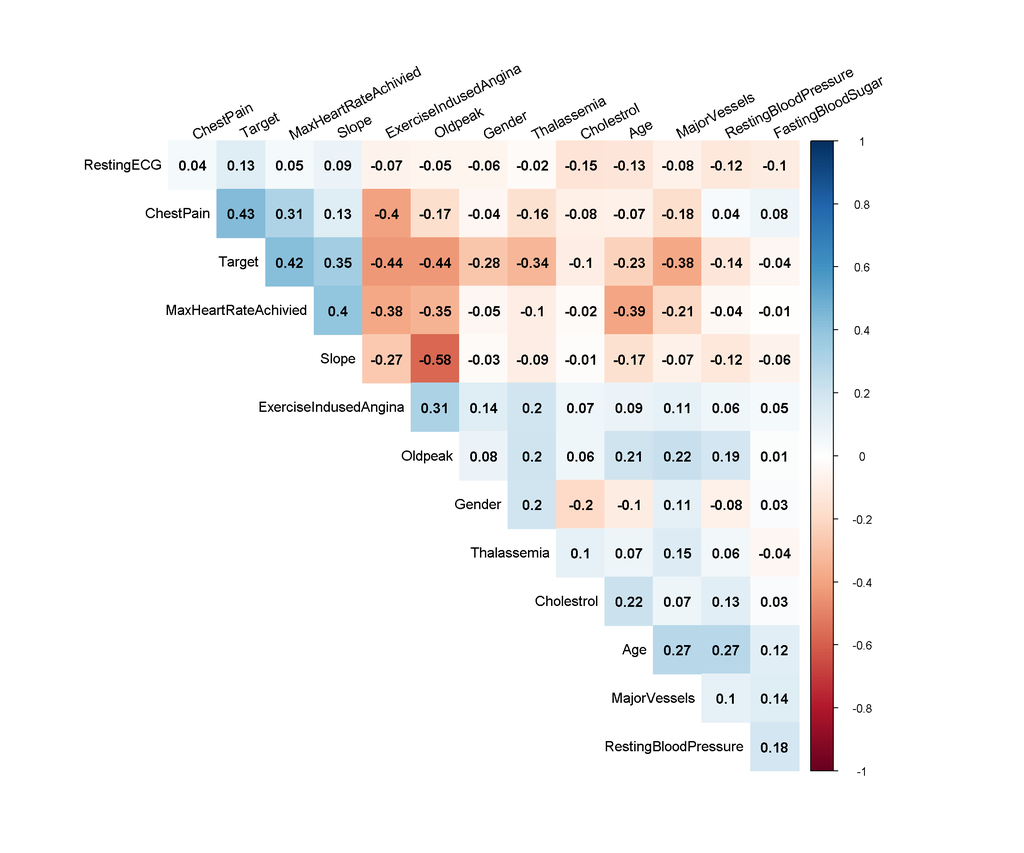

### Heart Health Graphs in Different Styles

*Minimal & custom colour*

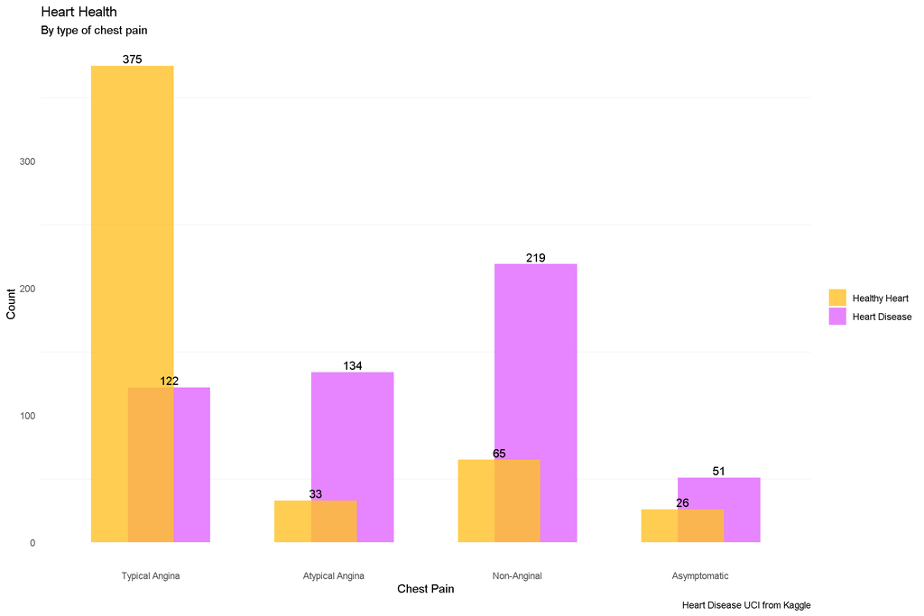

```r
posn_d <- position_dodge(width = 0.4)


heart %>%
  ggplot( aes(x = factor(ChestPain), fill = factor(Target))) +
  geom_bar(position = posn_d ,alpha = 0.8) +
  labs(x = "Chest Pain", y = "Count",title = "Heart Health", subtitle = "By type of chest pain", caption = "Heart Disease UCI from Kaggle") +
  geom_text(aes(label=..count..),stat="count",position=posn_d, vjust = -0.3) +
  scale_fill_manual("legend", values = c("Healthy Heart" = "goldenrod1", "Heart Disease" = "mediumorchid1")) +
  theme_minimal() +
  theme(legend.title = element_blank(),
        panel.grid.major = element_blank())
```

*Fivethirtyeight & custom colour*

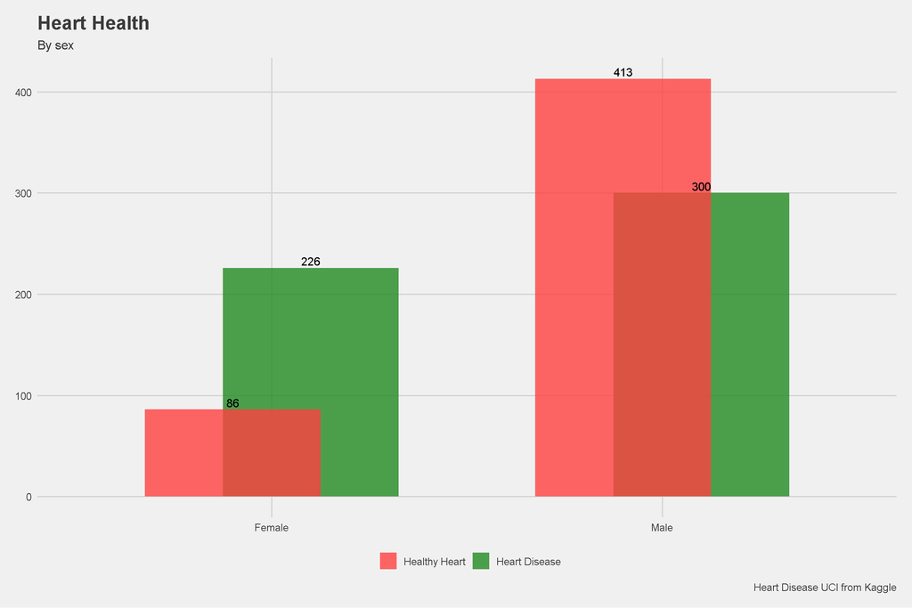

```r
heart %>%
  ggplot( aes(x = factor(Gender), fill = factor(Target)) ) +
  geom_bar(position = posn_d ,alpha = 0.8) +
  labs(x = "Sex",title = "Heart Health", subtitle = "By sex", caption = "Heart Disease UCI from Kaggle") +
  geom_text(aes(label=..count..),stat="count",position=posn_d, vjust = -0.3) +
  scale_color_fivethirtyeight() +
  theme_fivethirtyeight() +
  theme(legend.title = element_blank()) +
  scale_fill_manual("legend", values = c("Healthy Heart" = "brown1", "Heart Disease" = "forestgreen"))
```

*Stata theme*

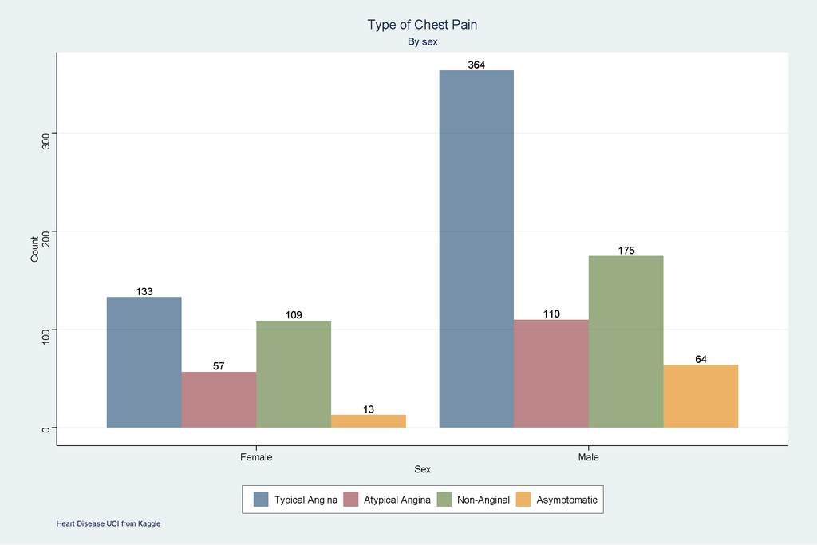

```r
heart %>%
  ggplot( aes(x = factor(Gender), fill = factor(ChestPain) )) +
  geom_bar(position = "dodge" ,alpha = 0.6) +
  labs(x = "Sex", y = "Count",title = "Type of Chest Pain", subtitle = "By sex", caption = "Heart Disease UCI from Kaggle") +
  geom_text(aes(label=..count..),stat="count",position=position_dodge(width = 0.9), vjust = -0.3) +
  theme_stata() + scale_fill_stata() +
  theme(legend.title = element_blank())
```

*Stata blue*

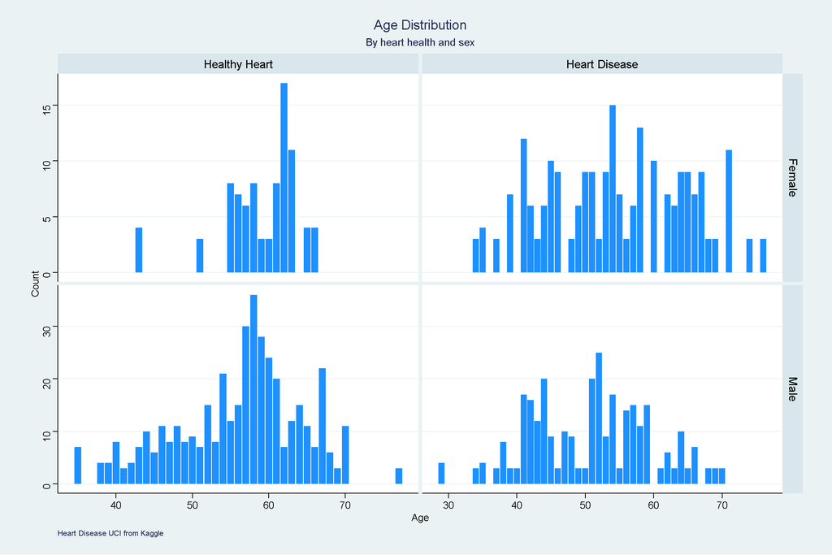

```r
heart[, .N, by = .(Age, Target, Gender)] %>%
  ggplot( aes(x = Age, y = N) ) +
  geom_col( fill = "dodgerblue") +
  facet_grid(Gender ~ Target, scales = "free") +
  labs( y = "Count",title = "Age Distribution", subtitle = "By heart health and sex", caption = "Heart Disease UCI from Kaggle") +
  theme_stata()
```

*Dotplot and histogram*

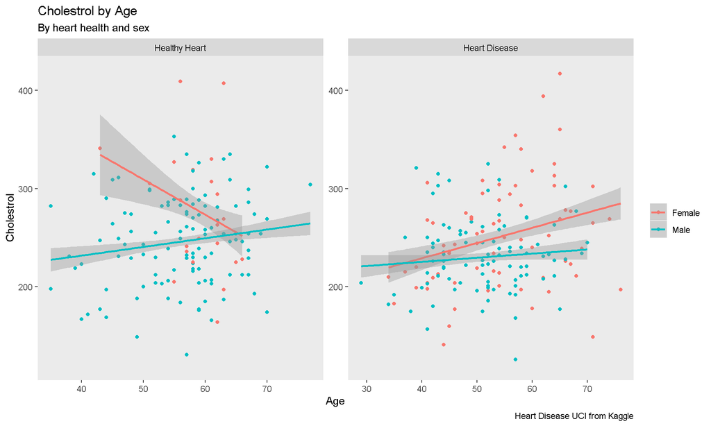

```r
heart %>%
  ggplot(aes(x=Age, y=Cholestrol, col = Gender)) +
  geom_point() +
  facet_wrap(~Target, scales = "free") +
  geom_smooth(method=lm) + ylim(120,420) +
  theme_grey() +
  labs(title = "Cholestrol by Age", subtitle = "By heart health and sex", caption = "Heart Disease UCI from Kaggle") +
  theme(legend.title = element_blank(),
        panel.grid.major = element_blank(),
        panel.grid.minor = element_blank())
```

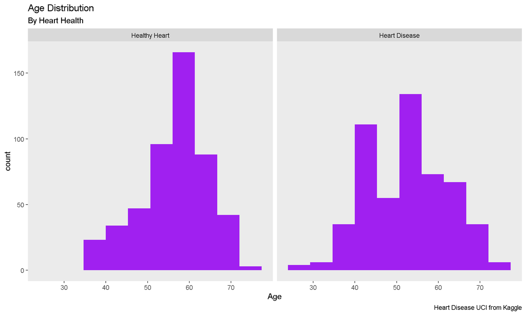

```r
heart %>%
  ggplot(aes(x=Age)) +
  geom_histogram( fill = "purple", bins = 10) +
  facet_wrap(~Target) +
  theme_grey() +
  labs(title = "Age Distribution", subtitle = "By Heart Health", caption = "Heart Disease UCI from Kaggle") +
  theme(panel.grid.major = element_blank(), panel.grid.minor = element_blank())
```

```r
 # facet_grid(Gender ~ Target, scales = "free")
```

## **Modeling**

### Training Data

```r
levels(heart$Target) <- make.names(levels(factor(heart$Target)))

set.seed(1337)

# Prepare the initial split object
data_split <- initial_split(heart, prop = 0.65)

# Extract the training dataframe
training_data <- training(data_split)

# Extract the testing dataframe
testing_data <- testing(data_split)



set.seed(1337)
cv_split <- vfold_cv(training_data, v = 5)

cv_data <- cv_split %>%
  mutate(train = map(splits, ~training(.x)),validate = map(splits, ~testing(.x)))


########################################################
myControl <- trainControl(
  method = "cv",
  number = 10,
  summaryFunction = twoClassSummary,              #twoClassSummary for logistic
  classProbs = TRUE,                              #Classifcation probabilities
  verboseIter = TRUE
)
########################################################
```

### Random Forest - Cross-Validated Models

```r
 cv_tune <- cv_data %>%
   expand_grid(mtry = 2:13) # mtry range 1:# of features

 #NOTE: crossing() has been updated, expand_grid() now replaces it.

cv_models_rf <- cv_tune %>%
  mutate(model = map2(train, mtry, ~ranger(formula = Target~.,
                                           data = .x, mtry = .y,
                                           num.trees = 2000, seed = 1337)))



cv_prep_rf <- cv_models_rf %>%
  mutate( validate_actual = map(validate, ~.x$Target == "Heart.Disease"),
           validate_predicted = map2(.x = model, .y = validate,
                                     ~predict(.x, .y, type = "response")$predictions == "Heart.Disease")
         )



# Recall on Random Forest models at different levels of mtry
cv_perf_recall <- cv_prep_rf %>%
  mutate(recall = map2_dbl(.x = validate_actual, .y = validate_predicted, ~recall(actual = .x, predicted = .y)))

temp <- cv_perf_recall %>%
  select(mtry, recall)
j = matrix(nrow = 12, ncol = 2)

for(i in 2:13){
  j[i-1,] = i
  j[i-1,2] = temp %>%
            filter(mtry == i) %>%
             summarize(mean_recall = mean(recall)) %>%
             as.numeric()
}

colnames(j) <-  c("mtry","mean_recall")
knitr::kable(as.data.frame(j))
```

| mtry | mean_recall |
| --- | --- |
| 2 | 0.9779728 |
| 3 | 0.9753061 |
| 4 | 0.9753061 |
| 5 | 0.9753061 |
| 6 | 0.9753061 |
| 7 | 0.9753061 |
| 8 | 0.9753061 |
| 9 | 0.9785848 |
| 10 | 0.9814017 |
| 11 | 0.9814017 |
| 12 | 0.9814017 |
| 13 | 0.9840683 |

```r
# Tuning mtry
cv_eval_tune <- cv_prep_rf %>%
 mutate(validate_mae = map2_dbl(.x = validate_actual, .y = validate_predicted, ~mae(actual = .x, predicted = .y)))


#################################################################
# Mean validate MAE for each fold and mtry combination
# cv_eval_tune %>%
#   group_by(mtry) %>%
#   summarise(mean_validate_mae = mean(validate_mae))
      #Not working it did before

# cv_eval_tune %>%
#   select(mtry, validate_mae) %>%
#   group_nest(mtry) %>%
#   unnest()
      #Kind of gets there
#################################################################





temp <- cv_eval_tune %>%
  select(mtry, validate_mae)
k = matrix(nrow = 12, ncol = 2)

for(i in 2:13){
  k[i-1,] = i
  k[i-1,2] = temp %>%
            filter(mtry == i) %>%
             summarize(mean_validate_mae = mean(validate_mae)) %>%
             as.numeric()
}

colnames(k) <-  c("mtry","mean_validate_mae")
knitr::kable(as.data.frame(k))
```

| mtry | mean_validate_mae |
| --- | --- |
| 2 | 0.0285265 |
| 3 | 0.0270228 |
| 4 | 0.0270228 |
| 5 | 0.0270228 |
| 6 | 0.0270228 |
| 7 | 0.0270228 |
| 8 | 0.0270228 |
| 9 | 0.0255190 |
| 10 | 0.0240153 |
| 11 | 0.0240153 |
| 12 | 0.0225115 |
| 13 | 0.0240265 |

The Mean Absolute Error (MAE) measures how much on average the predicted values differ from actual values, taking the mean of the MAE over different folds the hyperparameter mtry is best at 12.

On average the true positive rate (Sensitivity/Recall) seems to increase as mtry increases, in general. These predictive models performance quite well.

#### Model Results on Test Data

**Mean Absolute Error**

```r
best_model <- ranger(formula = Target~., data = training_data , mtry = 12, num.trees = 2000, seed = 1337)

test_actual <- testing_data$Target == "Heart.Disease"
test_predicted <- predict(best_model, testing_data, type = "response")$predictions == "Heart.Disease"

mae(test_actual, test_predicted)
```

```
[1] 0.008379888
```

**Accuracy** Measures how well the model predicted both TRUE and FALSE classes.

```r
Metrics::accuracy(test_actual,test_predicted)
```

```
[1] 0.9916201
```

**Precision** Calculates how often the model is correct at the TRUE class."

```r
Metrics::precision(test_actual,test_predicted)
```

```
[1] 0.9836066
```

### Logistic Regression - Cross-Validated Models

```r
cv_models_lr <- cv_data %>%
  mutate(model = map(train, ~glm(formula = Target~., data = .x, family = "binomial")))


# Examine the first model and validate
model <- cv_models_lr$model[[1]]
validate <- cv_models_lr$validate[[1]]



# Prepare binary vector of actual Heart Disease values in validate
validate_actual <- validate$Target == "Heart.Disease"

# Predict the probabilities for the observations in validate
validate_prob <- predict(model, validate, type = "response")


# Prepare binary vector of predicted Heart Disease values for validate
validate_predicted <- validate_prob > 0.5
# Compare the actual & predicted performance visually using a table

# table(validate_actual, validate_predicted)



ap.list <- matrix(nrow = 5, ncol = 2)

for(i in 1:5){
  m <- cv_models_lr$model[[i]]
  v <- cv_models_lr$validate[[i]]

  v_actual <- v$Target == "Heart.Disease"
  v_prob <- predict(m, v, type = "response")

  v_predicted <- v_prob > 0.5

               print(table(v_actual, v_predicted))


  ap.list[i,1] = Metrics::accuracy(v_actual, v_predicted)
  ap.list[i,2] = Metrics::precision(v_actual, v_predicted)

            if (i == 5){
              ap = apply(ap.list, 2, mean)
              print("Mean Accuracy")
              print(ap[1])
              print("Mean Precision")
              print(ap[2])
              }
}
```

```
        v_predicted
v_actual FALSE TRUE
   FALSE    43   16
   TRUE      3   72
        v_predicted
v_actual FALSE TRUE
   FALSE    48   12
   TRUE     17   57
        v_predicted
v_actual FALSE TRUE
   FALSE    51   11
   TRUE      9   62
        v_predicted
v_actual FALSE TRUE
   FALSE    58   10
   TRUE      5   60
        v_predicted
v_actual FALSE TRUE
   FALSE    58   14
   TRUE     10   51
[1] "Mean Accuracy"
[1] 0.8396364
[1] "Mean Precision"
[1] 0.8270684
```

*Confusion matrix of all the logistic regression models*  
Using a logistic regression model to predict heart disease, the metrics of interest will be accuracy and precision. We would like to know who does and does not have heart disease, as well as how correct that true classification is.  
*Mean Recall of training models*

```r
cv_prep_lr <- cv_models_lr %>%
  mutate(validate_actual = map(validate, ~.x$Target == "Heart.Disease"),
         validate_predicted = map2(.x = model, .y = validate,
                                   ~predict(.x, .y, type = "response") > 0.5)
         )

# Validate recall for each cross validation fold
cv_perf_recall <- cv_prep_lr %>%
  mutate(validate_recall = map2_dbl(validate_actual, validate_predicted,
                                    ~recall(actual = .x, predicted = .y)))


# cv_perf_recall$validate_recall
mean(cv_perf_recall$validate_recall)
```

```
[1] 0.8725304
```

#### Glmnet Modeling

```r
# Custom tuning grid for RF-modeling
# tune.grid <- data.frame(
#   .mtry = 2:length(heart),
#   .splitrule = "variance",
#   .min.node.size = 5
# )


# Custom tuning grid for Lasso or Ridge regression
tune.grid <- expand.grid(
  alpha = 0:1,
  lambda = seq(0.0001, 1, length = 20)
)


# Glmnet places constraints on coeff to prevent overfitting, fits a glm via maximum likelihood

# Ridge (0) or Lasso (1)
model.glmnet <- train(
  Target ~.,
  heart,
  metric = "ROC",
  tuneGrid = tune.grid,
  method = "glmnet",
  trControl = myControl,
  preProcess = c("medianImpute", "center", "scale")
)
```

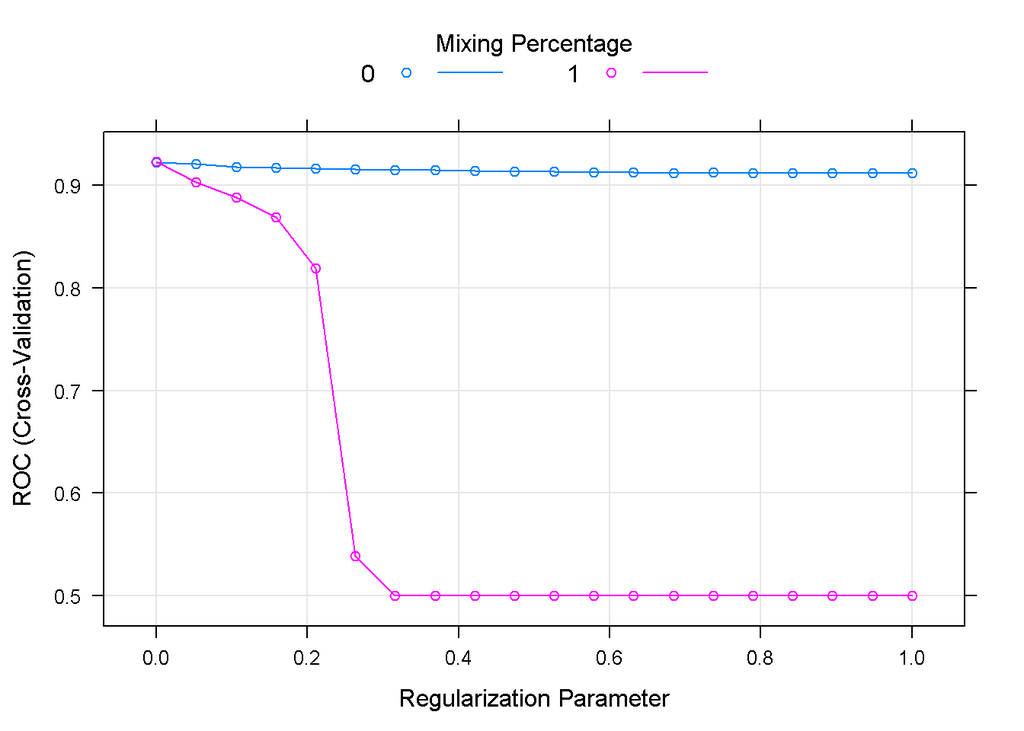

```r
plot(model.glmnet)
```

```r
model.glmnet
```

```
glmnet

1025 samples
  13 predictor
   2 classes: 'Healthy.Heart', 'Heart.Disease'

Pre-processing: median imputation (17), centered (17), scaled (17)
Resampling: Cross-Validated (10 fold)
Summary of sample sizes: 922, 923, 922, 923, 922, 923, ...
Resampling results across tuning parameters:

  alpha  lambda      ROC        Sens       Spec
  0      0.00010000  0.9220681  0.8116327  0.8879173
  0      0.05272632  0.9205358  0.8096327  0.8822206
  0      0.10535263  0.9181369  0.8076327  0.8727504
```

[output cut: 40 more lines]

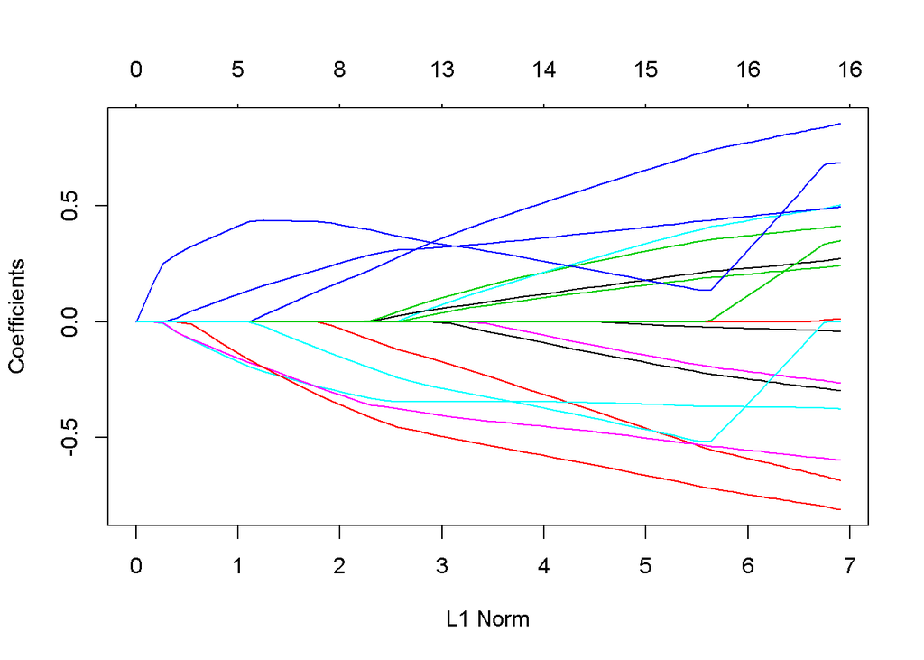

```r
#max(model.glmnet[["results"]][["ROC"]])
plot(model.glmnet$finalModel)
```

### Stepwise Selection - Logistic Regression

```r
model.0 <- glm(Target ~ 1, data = heart, family ="binomial")
model.1 <- glm(Target ~ . -Slope, data = heart, family = "binomial")

 step(model.0 , scope = formula(model.1), direction="forward", k = 2)
```

```
Start:  AIC=1422.24
Target ~ 1

                        Df Deviance    AIC
+ ChestPain              3   1124.0 1132.0
+ Thalassemia            3   1125.0 1133.0
+ Oldpeak                1   1195.3 1199.3
+ ExerciseIndusedAngina  1   1214.1 1218.1
+ MaxHeartRateAchivied   1   1219.6 1223.6
+ MajorVessels           1   1256.6 1260.6
+ Gender                 1   1337.8 1341.8
+ Age                    1   1365.1 1369.1
+ RestingBloodPressure   1   1400.3 1404.3
+ RestingECG             1   1401.6 1405.6
+ Cholestrol             1   1409.9 1413.9
<none>                       1420.2 1422.2
+ FastingBloodSugar      1   1418.5 1422.5

Step:  AIC=1131.99
Target ~ ChestPain

                        Df Deviance     AIC
+ Thalassemia            3   948.04  962.04
+ Oldpeak                1   993.33 1003.33
+ MajorVessels           1  1015.13 1025.13
+ MaxHeartRateAchivied   1  1040.05 1050.05
+ Gender                 1  1043.17 1053.17
+ ExerciseIndusedAngina  1  1063.34 1073.34
+ Age                    1  1092.20 1102.20
+ RestingBloodPressure   1  1106.02 1116.02
+ RestingECG             1  1114.53 1124.53
+ Cholestrol             1  1118.39 1128.39
+ FastingBloodSugar      1  1118.81 1128.81
<none>                      1123.99 1131.99

Step:  AIC=962.04
Target ~ ChestPain + Thalassemia

                        Df Deviance    AIC
+ MajorVessels           1   856.91 872.91
```

[output cut: 93 more lines]

```
                    Df Deviance    AIC
+ RestingECG         1   701.69 731.69
<none>                   708.85 736.85
+ Age                1   708.34 738.34
+ FastingBloodSugar  1   708.81 738.81

Step:  AIC=731.69
Target ~ ChestPain + Thalassemia + MajorVessels + Oldpeak + ExerciseIndusedAngina +
    Gender + MaxHeartRateAchivied + Cholestrol + RestingBloodPressure +
    RestingECG

                    Df Deviance    AIC
<none>                   701.69 731.69
+ Age                1   701.51 733.51
+ FastingBloodSugar  1   701.68 733.68
```

```
Call:  glm(formula = Target ~ ChestPain + Thalassemia + MajorVessels +
    Oldpeak + ExerciseIndusedAngina + Gender + MaxHeartRateAchivied +
    Cholestrol + RestingBloodPressure + RestingECG, family = "binomial",
    data = heart)

Coefficients:
             (Intercept)  ChestPainAtypical Angina
                0.000998                  1.130884
    ChestPainNon-Anginal     ChestPainAsymptomatic
                1.911585                  1.873335
            Thalassemia1              Thalassemia2
                1.717835                  1.756457
            Thalassemia3              MajorVessels
                0.335443                 -0.761845
                 Oldpeak    ExerciseIndusedAngina1
               -0.640488                 -0.812629
              GenderMale      MaxHeartRateAchivied
               -1.449652                  0.024614
              Cholestrol      RestingBloodPressure
               -0.006052                 -0.015617
              RestingECG
                0.513108

Degrees of Freedom: 1024 Total (i.e. Null);  1010 Residual
Null Deviance:      1420
Residual Deviance: 701.7    AIC: 731.7
```

```r
# formula = Target ~ ChestPain + Thalassemia + MajorVessels +
#    Oldpeak + ExerciseIndusedAngina + Gender + MaxHeartRateAchivied +
#    Cholestrol + RestingBloodPressure + RestingECG

model.heart <- glm(formula = Target ~ ChestPain + Thalassemia + MajorVessels +
    Oldpeak + ExerciseIndusedAngina + Gender + MaxHeartRateAchivied +
    Cholestrol + RestingBloodPressure + RestingECG, family = "binomial",
    data = heart)

summary(model.heart)
```

```
Call:
glm(formula = Target ~ ChestPain + Thalassemia + MajorVessels +
    Oldpeak + ExerciseIndusedAngina + Gender + MaxHeartRateAchivied +
    Cholestrol + RestingBloodPressure + RestingECG, family = "binomial",
    data = heart)

Deviance Residuals:
    Min       1Q   Median       3Q      Max
-2.5893  -0.4198   0.1205   0.5466   2.5864

Coefficients:
                          Estimate Std. Error z value Pr(>|z|)
(Intercept)               0.000998   1.448018   0.001 0.999450
ChestPainAtypical Angina  1.130884   0.295093   3.832 0.000127 ***
ChestPainNon-Anginal      1.911585   0.246880   7.743 9.71e-15 ***
ChestPainAsymptomatic     1.873335   0.339647   5.516 3.48e-08 ***
Thalassemia1              1.717835   1.103014   1.557 0.119375
Thalassemia2              1.756457   1.044426   1.682 0.092619 .
Thalassemia3              0.335443   1.048298   0.320 0.748977
MajorVessels             -0.761845   0.102930  -7.402 1.35e-13 ***
Oldpeak                  -0.640487   0.110271  -5.808 6.31e-09 ***
ExerciseIndusedAngina1   -0.812629   0.230142  -3.531 0.000414 ***
GenderMale               -1.449652   0.268969  -5.390 7.06e-08 ***
MaxHeartRateAchivied      0.024614   0.005171   4.760 1.94e-06 ***
Cholestrol               -0.006052   0.002048  -2.955 0.003131 **
RestingBloodPressure     -0.015617   0.005525  -2.827 0.004704 **
RestingECG                0.513108   0.192277   2.669 0.007617 **
---
Signif. codes:  0 '***' 0.001 '**' 0.01 '*' 0.05 '.' 0.1 ' ' 1

(Dispersion parameter for binomial family taken to be 1)

    Null deviance: 1420.24  on 1024  degrees of freedom
Residual deviance:  701.69  on 1010  degrees of freedom
AIC: 731.69

Number of Fisher Scoring iterations: 6
```